# Project: Personal Loan Campaign Modelling

Objective:

- create a model to determine which customers have a higher probability of purchasing the loan
- predict whether a liability customer will buy a personal loan or not
- detemine which variables are most significant
- determine which segment of customers should be targeted more

```python
import pandas as pd
import numpy as np
from sklearn import metrics
import matplotlib.pyplot as plt
%matplotlib inline
import seaborn as sns
from sklearn.model_selection import train_test_split
from sklearn.tree import DecisionTreeClassifier
from sklearn import tree
from sklearn.model_selection import GridSearchCV
from sklearn.metrics import accuracy_score, recall_score, precision_score, roc_auc_score, roc_curve, confusion_matrix, precision_recall_curve
```

```python
loans = pd.read_csv("Loan_Modelling.csv")
```

### Start EDA

```python
loans.head()
```

|  | ID | Age | Experience | Income | ZIPCode | Family | CCAvg | Education | Mortgage | Personal_Loan | Securities_Account | CD_Account | Online | CreditCard |
| --- | --- | --- | --- | --- | --- | --- | --- | --- | --- | --- | --- | --- | --- | --- |
| 0 | 1 | 25 | 1 | 49 | 91107 | 4 | 1.6 | 1 | 0 | 0 | 1 | 0 | 0 | 0 |
| 1 | 2 | 45 | 19 | 34 | 90089 | 3 | 1.5 | 1 | 0 | 0 | 1 | 0 | 0 | 0 |
| 2 | 3 | 39 | 15 | 11 | 94720 | 1 | 1.0 | 1 | 0 | 0 | 0 | 0 | 0 | 0 |
| 3 | 4 | 35 | 9 | 100 | 94112 | 1 | 2.7 | 2 | 0 | 0 | 0 | 0 | 0 | 0 |
| 4 | 5 | 35 | 8 | 45 | 91330 | 4 | 1.0 | 2 | 0 | 0 | 0 | 0 | 0 | 1 |

```python
loans.info()
```

```
<class 'pandas.core.frame.DataFrame'>
RangeIndex: 5000 entries, 0 to 4999
Data columns (total 14 columns):
 #   Column              Non-Null Count  Dtype
---  ------              --------------  -----
 0   ID                  5000 non-null   int64
 1   Age                 5000 non-null   int64
 2   Experience          5000 non-null   int64
 3   Income              5000 non-null   int64
 4   ZIPCode             5000 non-null   int64
 5   Family              5000 non-null   int64
 6   CCAvg               5000 non-null   float64
 7   Education           5000 non-null   int64
 8   Mortgage            5000 non-null   int64
 9   Personal_Loan       5000 non-null   int64
 10  Securities_Account  5000 non-null   int64
 11  CD_Account          5000 non-null   int64
 12  Online              5000 non-null   int64
 13  CreditCard          5000 non-null   int64
dtypes: float64(1), int64(13)
memory usage: 547.0 KB
```

```python
loans.describe(include="all")
```

|  | ID | Age | Experience | Income | ZIPCode | Family | CCAvg | Education | Mortgage | Personal_Loan | Securities_Account | CD_Account | Online | CreditCard |
| --- | --- | --- | --- | --- | --- | --- | --- | --- | --- | --- | --- | --- | --- | --- |
| count | 5000.000000 | 5000.000000 | 5000.000000 | 5000.000000 | 5000.000000 | 5000.000000 | 5000.000000 | 5000.000000 | 5000.000000 | 5000.000000 | 5000.000000 | 5000.00000 | 5000.000000 | 5000.000000 |
| mean | 2500.500000 | 45.338400 | 20.104600 | 73.774200 | 93169.257000 | 2.396400 | 1.937938 | 1.881000 | 56.498800 | 0.096000 | 0.104400 | 0.06040 | 0.596800 | 0.294000 |
| std | 1443.520003 | 11.463166 | 11.467954 | 46.033729 | 1759.455086 | 1.147663 | 1.747659 | 0.839869 | 101.713802 | 0.294621 | 0.305809 | 0.23825 | 0.490589 | 0.455637 |
| min | 1.000000 | 23.000000 | -3.000000 | 8.000000 | 90005.000000 | 1.000000 | 0.000000 | 1.000000 | 0.000000 | 0.000000 | 0.000000 | 0.00000 | 0.000000 | 0.000000 |
| 25% | 1250.750000 | 35.000000 | 10.000000 | 39.000000 | 91911.000000 | 1.000000 | 0.700000 | 1.000000 | 0.000000 | 0.000000 | 0.000000 | 0.00000 | 0.000000 | 0.000000 |
| 50% | 2500.500000 | 45.000000 | 20.000000 | 64.000000 | 93437.000000 | 2.000000 | 1.500000 | 2.000000 | 0.000000 | 0.000000 | 0.000000 | 0.00000 | 1.000000 | 0.000000 |
| 75% | 3750.250000 | 55.000000 | 30.000000 | 98.000000 | 94608.000000 | 3.000000 | 2.500000 | 3.000000 | 101.000000 | 0.000000 | 0.000000 | 0.00000 | 1.000000 | 1.000000 |
| max | 5000.000000 | 67.000000 | 43.000000 | 224.000000 | 96651.000000 | 4.000000 | 10.000000 | 3.000000 | 635.000000 | 1.000000 | 1.000000 | 1.00000 | 1.000000 | 1.000000 |

```python
loans.shape
```

```
(5000, 14)
```

```python
loans.nunique()
```

```
ID                    5000
Age                     45
Experience              47
Income                 162
ZIPCode                467
Family                   4
CCAvg                  108
Education                3
Mortgage               347
Personal_Loan            2
Securities_Account       2
CD_Account               2
Online                   2
CreditCard               2
dtype: int64
```

```python
loans.isnull().sum()

#shows there are no missing values in the data
```

```
ID                    0
Age                   0
Experience            0
Income                0
ZIPCode               0
Family                0
CCAvg                 0
Education             0
Mortgage              0
Personal_Loan         0
Securities_Account    0
CD_Account            0
Online                0
CreditCard            0
dtype: int64
```

#### Univariate Analysis

```
['ID', 'Age', 'Experience', 'Income', 'ZIPCode', 'Family', 'CCAvg', 'Education', 'Mortgage', 'Personal_Loan', 'Securities_Account', 'CD_Account', 'Online', 'CreditCard']
```

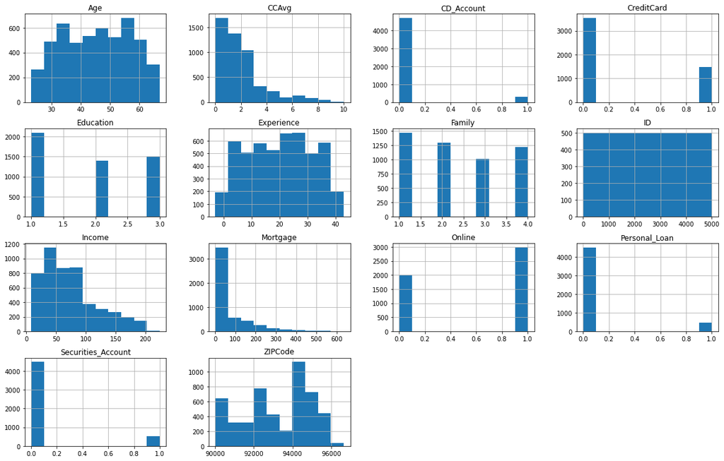

```python
plt.figure(figsize=(15,5))
cols = list(loans)

print (cols)
loans[cols].hist(stacked=False, bins=10, figsize=(20,40), layout=(12,4));
```

### Insights from Univariate Analysis:

#### Bivariate Analysis

```python
loans.corr()
```

|  | ID | Age | Experience | Income | ZIPCode | Family | CCAvg | Education | Mortgage | Personal_Loan | Securities_Account | CD_Account | Online | CreditCard |
| --- | --- | --- | --- | --- | --- | --- | --- | --- | --- | --- | --- | --- | --- | --- |
| ID | 1.000000 | -0.008473 | -0.008326 | -0.017695 | 0.002240 | -0.016797 | -0.024675 | 0.021463 | -0.013920 | -0.024801 | -0.016972 | -0.006909 | -0.002528 | 0.017028 |
| Age | -0.008473 | 1.000000 | 0.994215 | -0.055269 | -0.030530 | -0.046418 | -0.052012 | 0.041334 | -0.012539 | -0.007726 | -0.000436 | 0.008043 | 0.013702 | 0.007681 |
| Experience | -0.008326 | 0.994215 | 1.000000 | -0.046574 | -0.030456 | -0.052563 | -0.050077 | 0.013152 | -0.010582 | -0.007413 | -0.001232 | 0.010353 | 0.013898 | 0.008967 |
| Income | -0.017695 | -0.055269 | -0.046574 | 1.000000 | -0.030709 | -0.157501 | 0.645984 | -0.187524 | 0.206806 | 0.502462 | -0.002616 | 0.169738 | 0.014206 | -0.002385 |
| ZIPCode | 0.002240 | -0.030530 | -0.030456 | -0.030709 | 1.000000 | 0.027512 | -0.012188 | -0.008266 | 0.003614 | -0.002974 | 0.002422 | 0.021671 | 0.028317 | 0.024033 |
| Family | -0.016797 | -0.046418 | -0.052563 | -0.157501 | 0.027512 | 1.000000 | -0.109275 | 0.064929 | -0.020445 | 0.061367 | 0.019994 | 0.014110 | 0.010354 | 0.011588 |
| CCAvg | -0.024675 | -0.052012 | -0.050077 | 0.645984 | -0.012188 | -0.109275 | 1.000000 | -0.136124 | 0.109905 | 0.366889 | 0.015086 | 0.136534 | -0.003611 | -0.006689 |
| Education | 0.021463 | 0.041334 | 0.013152 | -0.187524 | -0.008266 | 0.064929 | -0.136124 | 1.000000 | -0.033327 | 0.136722 | -0.010812 | 0.013934 | -0.015004 | -0.011014 |
| Mortgage | -0.013920 | -0.012539 | -0.010582 | 0.206806 | 0.003614 | -0.020445 | 0.109905 | -0.033327 | 1.000000 | 0.142095 | -0.005411 | 0.089311 | -0.005995 | -0.007231 |
| Personal_Loan | -0.024801 | -0.007726 | -0.007413 | 0.502462 | -0.002974 | 0.061367 | 0.366889 | 0.136722 | 0.142095 | 1.000000 | 0.021954 | 0.316355 | 0.006278 | 0.002802 |
| Securities_Account | -0.016972 | -0.000436 | -0.001232 | -0.002616 | 0.002422 | 0.019994 | 0.015086 | -0.010812 | -0.005411 | 0.021954 | 1.000000 | 0.317034 | 0.012627 | -0.015028 |
| CD_Account | -0.006909 | 0.008043 | 0.010353 | 0.169738 | 0.021671 | 0.014110 | 0.136534 | 0.013934 | 0.089311 | 0.316355 | 0.317034 | 1.000000 | 0.175880 | 0.278644 |
| Online | -0.002528 | 0.013702 | 0.013898 | 0.014206 | 0.028317 | 0.010354 | -0.003611 | -0.015004 | -0.005995 | 0.006278 | 0.012627 | 0.175880 | 1.000000 | 0.004210 |
| CreditCard | 0.017028 | 0.007681 | 0.008967 | -0.002385 | 0.024033 | 0.011588 | -0.006689 | -0.011014 | -0.007231 | 0.002802 | -0.015028 | 0.278644 | 0.004210 | 1.000000 |

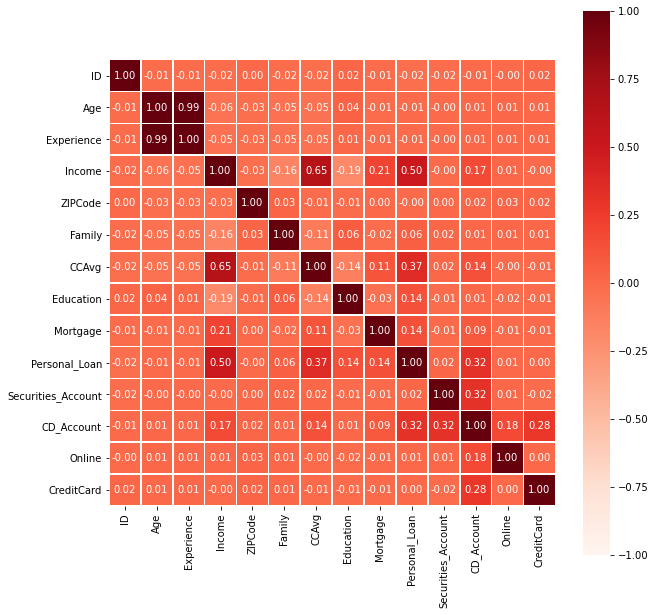

```python
plt.subplots(figsize=(10,10))
sns.heatmap(loans.corr(),cmap='Reds',annot=True, fmt=".2f", vmin=-1, vmax=1, center= 0, square=True, linewidths=.7)
```

#### Insights from EDA:

- there are no missing values

#### Univariate Analysis insights:

- there are some outliers, but we can fix this in pre processing

#### Bivariate Analysis insights:

- there seems to be a strong correlation between experience and age (r = 0.99)
- there seems to be a strong correlation between CCAvg and Income (r = 0.65)
- there is a noteable correlation between income and personal_loan (r = 0.50)

### 1. Deal with outliers

```python
#from the descriptive statistics of the data, I noticed that
#the minimum experience was -3 years, which is not possible, so I will deal with this

loans_less_than = loans[loans["Experience"]<0]
loans_less_than.count()

#this shows us that there are 52 rows with experience that is less than 0 years,
#since this is an outlier, I will replace these rows with the median number

loans["Experience"].mask(loans["Experience"]<0, inplace =True)
loans["Experience"].isnull().sum()
loans['Experience'].fillna((loans['Experience'].median()), inplace=True)

loans.describe()
##the descriptive statistics show that there are no negative values in the experience column
```

|  | ID | Age | Experience | Income | ZIPCode | Family | CCAvg | Education | Mortgage | Personal_Loan | Securities_Account | CD_Account | Online | CreditCard |
| --- | --- | --- | --- | --- | --- | --- | --- | --- | --- | --- | --- | --- | --- | --- |
| count | 5000.000000 | 5000.000000 | 5000.000000 | 5000.000000 | 5000.000000 | 5000.000000 | 5000.000000 | 5000.000000 | 5000.000000 | 5000.000000 | 5000.000000 | 5000.00000 | 5000.000000 | 5000.000000 |
| mean | 2500.500000 | 45.338400 | 20.327600 | 73.774200 | 93169.257000 | 2.396400 | 1.937938 | 1.881000 | 56.498800 | 0.096000 | 0.104400 | 0.06040 | 0.596800 | 0.294000 |
| std | 1443.520003 | 11.463166 | 11.253035 | 46.033729 | 1759.455086 | 1.147663 | 1.747659 | 0.839869 | 101.713802 | 0.294621 | 0.305809 | 0.23825 | 0.490589 | 0.455637 |
| min | 1.000000 | 23.000000 | 0.000000 | 8.000000 | 90005.000000 | 1.000000 | 0.000000 | 1.000000 | 0.000000 | 0.000000 | 0.000000 | 0.00000 | 0.000000 | 0.000000 |
| 25% | 1250.750000 | 35.000000 | 11.000000 | 39.000000 | 91911.000000 | 1.000000 | 0.700000 | 1.000000 | 0.000000 | 0.000000 | 0.000000 | 0.00000 | 0.000000 | 0.000000 |
| 50% | 2500.500000 | 45.000000 | 20.000000 | 64.000000 | 93437.000000 | 2.000000 | 1.500000 | 2.000000 | 0.000000 | 0.000000 | 0.000000 | 0.00000 | 1.000000 | 0.000000 |
| 75% | 3750.250000 | 55.000000 | 30.000000 | 98.000000 | 94608.000000 | 3.000000 | 2.500000 | 3.000000 | 101.000000 | 0.000000 | 0.000000 | 0.00000 | 1.000000 | 1.000000 |
| max | 5000.000000 | 67.000000 | 43.000000 | 224.000000 | 96651.000000 | 4.000000 | 10.000000 | 3.000000 | 635.000000 | 1.000000 | 1.000000 | 1.00000 | 1.000000 | 1.000000 |

```
['Age', 'Experience', 'Income', 'ZIPCode', 'Family', 'CCAvg', 'Education', 'Mortgage']
```

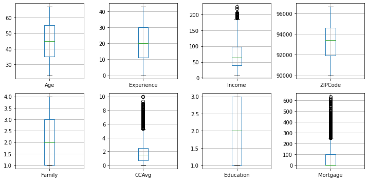

```python
##lets see if there are any outliers in the rest of the data
fig, axes = plt.subplots(2, 4, figsize=(10, 5))

cols1 = cols.copy()
cols1.remove("ID")
cols1.remove("Personal_Loan")
cols1.remove("Securities_Account")
cols1.remove("CD_Account")
cols1.remove("Online")
cols1.remove("CreditCard")

print (cols1)
len(cols1)
count =0
for i in range (0,2):
    for j in range (0,4):
        loans.boxplot (ax = axes[i,j], column = cols1[count])
        count +=1

plt.tight_layout()

#this shows us that there are some outliers for income, CCavg, and mortgage, however, since these are all
#skewed right, we will deal with transformations with this data later in the modelling process
```

```python
#loans["Mortgage"] = np.log1p(loans["Mortgage"])
#loans["Mortgage"].hist()
```

```python
##drop the ID row since it is not useful
loans.drop(["ID"], axis =1, inplace=True)
```

```python
loans.describe()
```

|  | Age | Experience | Income | ZIPCode | Family | CCAvg | Education | Mortgage | Personal_Loan | Securities_Account | CD_Account | Online | CreditCard |
| --- | --- | --- | --- | --- | --- | --- | --- | --- | --- | --- | --- | --- | --- |
| count | 5000.000000 | 5000.000000 | 5000.000000 | 5000.000000 | 5000.000000 | 5000.000000 | 5000.000000 | 5000.000000 | 5000.000000 | 5000.000000 | 5000.00000 | 5000.000000 | 5000.000000 |
| mean | 45.338400 | 20.327600 | 73.774200 | 93169.257000 | 2.396400 | 1.937938 | 1.881000 | 56.498800 | 0.096000 | 0.104400 | 0.06040 | 0.596800 | 0.294000 |
| std | 11.463166 | 11.253035 | 46.033729 | 1759.455086 | 1.147663 | 1.747659 | 0.839869 | 101.713802 | 0.294621 | 0.305809 | 0.23825 | 0.490589 | 0.455637 |
| min | 23.000000 | 0.000000 | 8.000000 | 90005.000000 | 1.000000 | 0.000000 | 1.000000 | 0.000000 | 0.000000 | 0.000000 | 0.00000 | 0.000000 | 0.000000 |
| 25% | 35.000000 | 11.000000 | 39.000000 | 91911.000000 | 1.000000 | 0.700000 | 1.000000 | 0.000000 | 0.000000 | 0.000000 | 0.00000 | 0.000000 | 0.000000 |
| 50% | 45.000000 | 20.000000 | 64.000000 | 93437.000000 | 2.000000 | 1.500000 | 2.000000 | 0.000000 | 0.000000 | 0.000000 | 0.00000 | 1.000000 | 0.000000 |
| 75% | 55.000000 | 30.000000 | 98.000000 | 94608.000000 | 3.000000 | 2.500000 | 3.000000 | 101.000000 | 0.000000 | 0.000000 | 0.00000 | 1.000000 | 1.000000 |
| max | 67.000000 | 43.000000 | 224.000000 | 96651.000000 | 4.000000 | 10.000000 | 3.000000 | 635.000000 | 1.000000 | 1.000000 | 1.00000 | 1.000000 | 1.000000 |

### Split the data

```python
X = loans.drop("Personal_Loan", axis =1)
y = loans["Personal_Loan"]
```

```python
X_train, X_test, y_train, y_test = train_test_split(X, y, test_size=.30, random_state=7)
```

```python
print("Original True Values    : {0} ({1:0.2f}%)".format(len(loans.loc[loans['Personal_Loan'] == 1]), (len(loans.loc[loans['Personal_Loan'] == 1])/len(loans.index)) * 100))
print("Original False Values   : {0} ({1:0.2f}%)".format(len(loans.loc[loans['Personal_Loan'] == 0]), (len(loans.loc[loans['Personal_Loan'] == 0])/len(loans.index)) * 100), '\n')

print("Training loan True Values    : {0} ({1:0.2f}%)".format(len(y_train[y_train[:] == 1]), (len(y_train[y_train[:] == 1])/len(y_train)) * 100))
print("Training loan False Values   : {0} ({1:0.2f}%)".format(len(y_train[y_train[:] == 0]), (len(y_train[y_train[:] == 0])/len(y_train)) * 100), '\n')

print("Test loan True Values        : {0} ({1:0.2f}%)".format(len(y_test[y_test[:] == 1]), (len(y_test[y_test[:] == 1])/len(y_test)) * 100))
print("Test loan False Values       : {0} ({1:0.2f}%)".format(len(y_test[y_test[:] == 0]), (len(y_test[y_test[:] == 0])/len(y_test)) * 100))
```

```
Original True Values    : 480 (9.60%)
Original False Values   : 4520 (90.40%)

Training loan True Values    : 342 (9.77%)
Training loan False Values   : 3158 (90.23%)

Test loan True Values        : 138 (9.20%)
Test loan False Values       : 1362 (90.80%)
```

#### Insights from Data Pre Processing

- There are no longer any outliers in Experience
- We don't need to do one hot encoding since all of the variables are numeric
- We don't need to feature engineer since all of the variables are numeric

### Testing the assumptions of logistic regression

- In this section, I will test the assumptions of logistic regression:
  1. is the dependent variable binary?
  2. is there a large sample size?
  3. is there an absence of mulitcollinearity?

### Answering logistic regressison assumption

1. The dependent variable is binary: either the curtomer took the loan or did not
2. The sample size is large (5000 independent observations)
3. Abscence of multicollinearity (below)

```python
X_train1 = X_train.copy()
X_train1['constant'] = 1
X_train1
```

|  | Age | Experience | Income | ZIPCode | Family | CCAvg | Education | Mortgage | Securities_Account | CD_Account | Online | CreditCard | constant |
| --- | --- | --- | --- | --- | --- | --- | --- | --- | --- | --- | --- | --- | --- |
| 717 | 59 | 34.0 | 94 | 93940 | 3 | 0.50 | 1 | 0 | 0 | 0 | 0 | 1 | 1 |
| 2496 | 63 | 37.0 | 32 | 93117 | 3 | 0.70 | 2 | 141 | 0 | 0 | 0 | 0 | 1 |
| 2469 | 43 | 18.0 | 89 | 92780 | 1 | 0.10 | 2 | 307 | 0 | 0 | 0 | 1 | 1 |
| 1375 | 50 | 26.0 | 179 | 92612 | 1 | 2.90 | 3 | 0 | 0 | 0 | 0 | 1 | 1 |
| 2742 | 39 | 14.0 | 89 | 95762 | 2 | 0.40 | 1 | 0 | 0 | 0 | 1 | 0 | 1 |
| ... | ... | ... | ... | ... | ... | ... | ... | ... | ... | ... | ... | ... | ... |
| 4307 | 45 | 19.0 | 128 | 94928 | 4 | 6.00 | 3 | 0 | 0 | 0 | 1 | 0 | 1 |
| 2550 | 32 | 8.0 | 20 | 93106 | 1 | 0.50 | 3 | 102 | 0 | 0 | 1 | 0 | 1 |
| 537 | 44 | 20.0 | 131 | 90717 | 1 | 4.90 | 3 | 0 | 0 | 0 | 1 | 0 | 1 |
| 1220 | 41 | 17.0 | 165 | 94143 | 2 | 8.00 | 1 | 0 | 0 | 0 | 1 | 0 | 1 |
| 4271 | 25 | 1.0 | 150 | 92507 | 1 | 6.33 | 1 | 0 | 0 | 0 | 0 | 0 | 1 |

3500 rows × 13 columns

```python
# for statistical analysis
import statsmodels.stats.api as sms
from statsmodels.stats.outliers_influence import variance_inflation_factor

vif_series1 = pd.Series([variance_inflation_factor(X_train1.values,i) for i in range(X_train1.shape[1])],index=X_train1.columns, dtype = float)
print('Series before feature selection: \n\n{}\n'.format(vif_series1))
```

```
Series before feature selection:

Age                     22.037624
Experience              21.990150
Income                   1.841594
ZIPCode                  1.007228
Family                   1.037052
CCAvg                    1.674281
Education                1.055811
Mortgage                 1.068913
Securities_Account       1.167275
CD_Account               1.359467
Online                   1.040201
CreditCard               1.099809
constant              2955.175725
dtype: float64
```

```python
X_train2 = X_train1.drop('Experience', axis=1)
vif_series2 = pd.Series([variance_inflation_factor(X_train2.values,i) for i in range(X_train2.shape[1])],index=X_train2.columns)
print('Series before feature selection: \n\n{}\n'.format(vif_series2))
```

```
Series before feature selection:

Age                      1.011480
Income                   1.841583
ZIPCode                  1.007185
Family                   1.036824
CCAvg                    1.674006
Education                1.044350
Mortgage                 1.068396
Securities_Account       1.167274
CD_Account               1.359466
Online                   1.040150
CreditCard               1.099789
constant              2859.714970
dtype: float64
```

### Insights on model performance evaluation and improvement

- According to the VIF, age or experience were highly multicollinear
- when the logistic regression analysis is done with the removal of the "age" column, the odds ratio is a little more representative on the final analysis:
  - The odds ratio of income is 0.035
  - The odds ratio of family is 0.034
  - the odds ratio of education is 0.038
  - an image of the odds ratio with the "age" column remove can be found here:

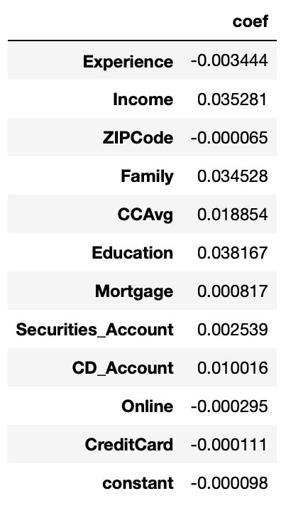

- however, if these columns were excluded from the analysis, the logistic regression model was not a good fit on the data
- therefore, these columns were kept in
- based on the results of the logistic regression and the decision tree, the columns for age and experience were not important, so keeping this data will not profoundly impact the final analysis

## Logistic Regression

```python
from sklearn import metrics

from sklearn.linear_model import LogisticRegression

# Fit the model on train
model = LogisticRegression(solver="liblinear")
model.fit(X_train, y_train)
#predict on test
y_predict = model.predict(X_test)
```

```python
coef_df = pd.DataFrame(model.coef_)
coef_df['Intercept'] = model.intercept_
print(coef_df)
```

```
          0         1         2        3        4         5         6  \
0  0.010641  0.005293  0.034375 -0.00007  0.01393  0.008256  0.015402

          7         8         9        10        11  Intercept
0  0.000891  0.001027  0.004072 -0.000111 -0.000032  -0.000039
```

```python
logmodel_score = model.score(X_test, y_test)
print(logmodel_score)
```

```
0.918
```

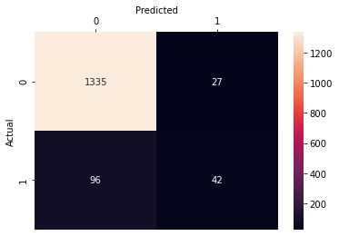

```python
y_predict = model.predict(X_test)

confusion_matrix=metrics.confusion_matrix(y_test, y_predict)
df_confusion = pd.DataFrame(confusion_matrix)

f, ax = plt.subplots(figsize=(6, 4))
sns.heatmap(df_confusion, annot=True, fmt="d")
ax.xaxis.set_ticks_position('top')
ax.xaxis.set_label_position('top')
plt.ylabel("Actual")
plt.xlabel("Predicted")
```

```python
#misclassified log pd

loans1= loans.copy()

log_reg_predict = y_predict.copy()

pred_class  = np.where(log_reg_predict >0, "Yes", "No") #for binary(Yes/No) category
predictions = pd.DataFrame(pred_class, columns=['log_reg_predict'])
my_new_df_log = pd.concat([loans1, predictions], axis =1)

my_new_df_log.head()
```

|  | Age | Experience | Income | ZIPCode | Family | CCAvg | Education | Mortgage | Personal_Loan | Securities_Account | CD_Account | Online | CreditCard | log_reg_predict |
| --- | --- | --- | --- | --- | --- | --- | --- | --- | --- | --- | --- | --- | --- | --- |
| 0 | 25 | 1.0 | 49 | 91107 | 4 | 1.6 | 1 | 0 | 0 | 1 | 0 | 0 | 0 | No |
| 1 | 45 | 19.0 | 34 | 90089 | 3 | 1.5 | 1 | 0 | 0 | 1 | 0 | 0 | 0 | No |
| 2 | 39 | 15.0 | 11 | 94720 | 1 | 1.0 | 1 | 0 | 0 | 0 | 0 | 0 | 0 | No |
| 3 | 35 | 9.0 | 100 | 94112 | 1 | 2.7 | 2 | 0 | 0 | 0 | 0 | 0 | 0 | No |
| 4 | 35 | 8.0 | 45 | 91330 | 4 | 1.0 | 2 | 0 | 0 | 0 | 0 | 0 | 1 | No |

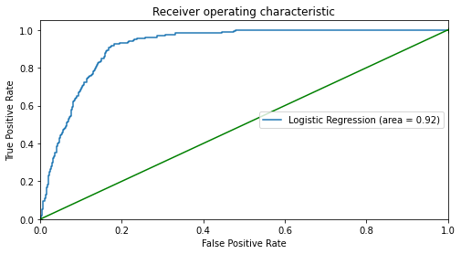

```python
logit_roc_auc_train = roc_auc_score(y_train, model.predict_proba(X_train)[:,1])
fpr, tpr, thresholds = roc_curve(y_train, model.predict_proba(X_train)[:,1])
plt.figure(figsize=(8,4))
plt.plot(fpr, tpr, label='Logistic Regression (area = %0.2f)' % logit_roc_auc_train)
plt.plot([0, 1], [0, 1],'g+-')
plt.xlim([0.0, 1.0])
plt.ylim([0.0, 1.05])
plt.xlabel('False Positive Rate')
plt.ylabel('True Positive Rate')
plt.title('Receiver operating characteristic')
plt.legend(loc="right")
plt.show()
```

### Takeaways from logistic regression and the confusion matrix

- Our logistic regression fit the test data well at 0.918
- However, since the coefficients dont mean much, we can not tell true relationships between the data
- True Positives (TP): we correctly predicted that the customers took a loan: 42
- True Negatives (TN): we correctly predicted that the customers didn't take a loan: 1335
- False Positives (FP)/Type I error: we incorrectly predicted that the customers took a loan: 27
- False Negatives (FN)/Type II error: we incorrectly predicted that they didn't take a loan: 96

```python
scores=[]
# To get diferent metric scores
from sklearn import metrics
from sklearn.metrics import accuracy_score, recall_score, precision_score, roc_auc_score, roc_curve, confusion_matrix, precision_recall_curve
from sklearn.model_selection import GridSearchCV

def scores(model, X_train, y_train, X_test, y_test):
    pred_train = model.predict(X_train)
    pred_test = model.predict(X_test)

    train_acc = accuracy_score(pred_train,y_train)
    test_acc = accuracy_score(pred_test,y_test)

    train_recall = recall_score(y_train,pred_train)
    test_recall = recall_score(y_test,pred_test)

    train_precision = precision_score(y_train,pred_train)
    test_precision = precision_score(y_test,pred_test)

    print("Accuracy on training set : ",accuracy_score(pred_train,y_train))
    print("Accuracy on test set : ",accuracy_score(pred_test,y_test), "\n")
    print("Recall on training set : ",recall_score(y_train,pred_train))
    print("Recall on test set : ",recall_score(y_test,pred_test), "\n")
    print("Precision on training set : ",precision_score(y_train,pred_train))
    print("Precision on test set : ",precision_score(y_test,pred_test))
```

```python
scores(model,X_train, y_train, X_test, y_test )
```

```
Accuracy on training set :  0.9048571428571428
Accuracy on test set :  0.918

Recall on training set :  0.30701754385964913
Recall on test set :  0.30434782608695654

Precision on training set :  0.5223880597014925
Precision on test set :  0.6086956521739131
```

### Takeaways from the model performance metrics

- since this is a model on what type of customers to give out loans, we should focus on the instances in which the bank did not give out loans to the customers that should have gotten loans (the false negatives)
- the most loss for this bank, in this model, will be when they do not give out loans to customers who would have accepted them
- therefore, this model should focus on imroving recall
- in the model, as it is, the recall is slightly higher in the training data: 30.7% vs 30.4%
- To increase the recall , I will look at the odds coefficient and the Precision-Recall curve

```python
###Odds coefficient
log_odds = model.coef_[0]
pd.DataFrame(log_odds, X_train.columns, columns=['coef'])
```

|  | coef |
| --- | --- |
| Age | 0.010641 |
| Experience | 0.005293 |
| Income | 0.034375 |
| ZIPCode | -0.000070 |
| Family | 0.013930 |
| CCAvg | 0.008256 |
| Education | 0.015402 |
| Mortgage | 0.000891 |
| Securities_Account | 0.001027 |
| CD_Account | 0.004072 |
| Online | -0.000111 |
| CreditCard | -0.000032 |

- there are no strong coefficients for the dataset that stand out at a first glance
- the only notable coefficient is for income where an increase in 1% of income would lead to a 3% chance of the customer accepting the loan
- as the size of the family increases by 1%, the odds of the customer taking aloan increase by 1.4%

```python
# Optimal threshold as per AUC-ROC curve
# The optimal cut off would be where tpr is high and fpr is low
fpr, tpr, thresholds = metrics.roc_curve(y_test, model.predict_proba(X_test)[:,1])

optimal_idx = np.argmax(tpr - fpr)
optimal_threshold = thresholds[optimal_idx]
print(optimal_threshold)
```

```
0.09359340416742176
```

```python
# Model prediction with optimal threshold
pred_train_opt = (model.predict(X_train)>optimal_threshold).astype(int)
pred_test_opt = (model.predict(X_test)>optimal_threshold).astype(int)
```

```python
#Model performance with optimal threhold

print('Accuracy on train data:',accuracy_score(y_train, pred_train_opt) )
print('Accuracy on test data:',accuracy_score(y_test, pred_test_opt), "\n")

print('Recall on train data:',recall_score(y_train, pred_train_opt))
print('Recall on test data:',recall_score(y_test, pred_test_opt), "\n")

print('Precision on train data:',precision_score(y_train, pred_train_opt) )
print('Precision on test data:',precision_score(y_test, pred_test_opt))
```

```
Accuracy on train data: 0.9048571428571428
Accuracy on test data: 0.918

Recall on train data: 0.30701754385964913
Recall on test data: 0.30434782608695654

Precision on train data: 0.5223880597014925
Precision on test data: 0.6086956521739131
```

- There was no change in the model performance with optimal threshold.

#### Precision-recall curve

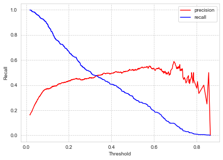

```python
import matplotlib.ticker as ticker

y_scores=model.predict_proba(X_train)[:,1]
prec, rec, tre = precision_recall_curve(y_train, y_scores,)

def plot_prec_recall_vs_thresh(precisions, recalls, thresholds):
    plt.plot(thresholds, precisions[:-1], 'r', label='precision')
    plt.plot(thresholds, recalls[:-1], 'b', label = 'recall')
    plt.xlabel('Threshold')
    plt.ylabel("Recall")
    plt.legend(loc='upper right')
plt.figure(figsize=(7,5))
sns.set_style("whitegrid", {'grid.linestyle': '--'})
ax.xaxis.set_major_formatter(ticker.FormatStrFormatter('%0.1f'))
plot_prec_recall_vs_thresh(prec, rec, tre)
plt.show()
```

```python
optimal_threshold = 0.30

# Model prediction with optimal threshold
pred_train_optimal = (model.predict_proba(X_train)[:,1]>optimal_threshold)
pred_test_optimal = (model.predict_proba(X_test)[:,1]>optimal_threshold)

#Model performance with optimal threhold

print('Accuracy on train data:',accuracy_score(y_train, pred_train_optimal) )
print('Accuracy on test data:',accuracy_score(y_test, pred_test_optimal), "\n")

print('Recall on train data:',recall_score(y_train, pred_train_optimal))
print('Recall on test data:',recall_score(y_test, pred_test_optimal), "\n")

print('Precision on train data:',precision_score(y_train, pred_train_optimal) )
print('Precision on test data:',precision_score(y_test, pred_test_optimal), "\n")

print('ROC-AUC Score on train data:',roc_auc_score(y_train, pred_train_optimal) )
print('ROC-AUC Score on test data:',roc_auc_score(y_test, pred_test_optimal))
```

```
Accuracy on train data: 0.8937142857142857
Accuracy on test data: 0.906

Recall on train data: 0.5087719298245614
Recall on test data: 0.5289855072463768

Precision on train data: 0.4603174603174603
Precision on test data: 0.4899328859060403

ROC-AUC Score on train data: 0.7220870415430597
ROC-AUC Score on test data: 0.7365926067803104
```

```python
##the original model scores:

scores(model,X_train, y_train, X_test, y_test )
```

```
Accuracy on training set :  0.9048571428571428
Accuracy on test set :  0.918

Recall on training set :  0.30701754385964913
Recall on test set :  0.30434782608695654

Precision on training set :  0.5223880597014925
Precision on test set :  0.6086956521739131
```

### Insights on improving the model

- I have visually compared the outputs before optimization and after
- We have an improved recall (it went from 0.304 on the original test data to 0.53 on the final test data)
- We decresead test accuracy slightly (0.92 on the original test data to 0.91 on the final test data)
- precision also descreased on the test data (0.61 on the original test data, and 0.49 on the final test data)

## Building a decision tree

```python
X_train, X_test, y_train, y_test = train_test_split(X, y, test_size=.30, random_state=6)
```

```python
decision_tree = DecisionTreeClassifier(criterion = 'gini', random_state=1)
decision_tree.fit(X_train, y_train)
```

```
DecisionTreeClassifier(random_state=1)
```

- since the goal is to find people that will take the loan, the bank will lose the most by not offering the loan to people
- with this as the goal, we should focus the most on improving recall, that is, focus on the people that will take the loan over not offering the loan to people that wouldn't take the loan

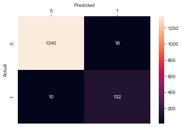

```python
y_predict = decision_tree.predict(X_test)

confusion_matrix=metrics.confusion_matrix(y_test, y_predict)
df_confusion = pd.DataFrame(confusion_matrix)

f, ax = plt.subplots(figsize=(6, 4))
sns.heatmap(df_confusion, annot=True, fmt="d")
ax.xaxis.set_ticks_position('top')
ax.xaxis.set_label_position('top')
plt.ylabel("Actual")
plt.xlabel("Predicted")
```

```python
#misclassified decision tree df

decision_tree_predict = y_predict.copy()

pred_class  = np.where(decision_tree_predict >0.5, "Yes", "No") #for binary(Yes/No) category
predictions = pd.DataFrame(pred_class, columns=['dtree_predict'])
my_new_df_dtree = pd.concat([loans1, predictions], axis =1)
```

```python
feature_names = list(X.columns)
print(feature_names)
```

```
['Age', 'Experience', 'Income', 'ZIPCode', 'Family', 'CCAvg', 'Education', 'Mortgage', 'Securities_Account', 'CD_Account', 'Online', 'CreditCard']
```

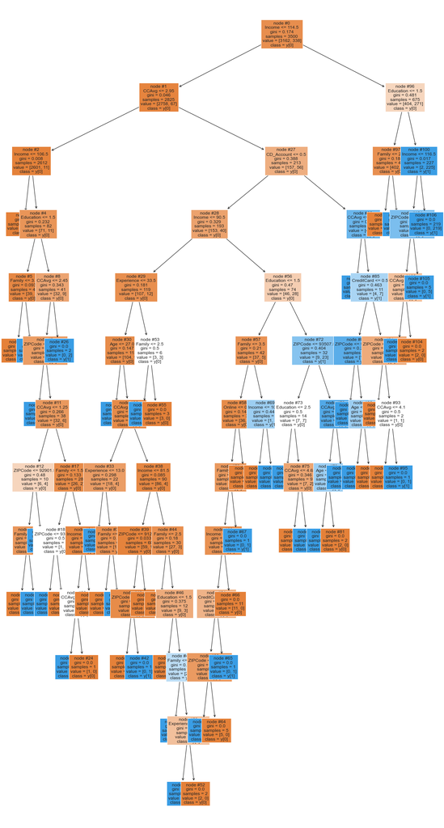

```python
plt.figure(figsize=(20,40))
out = tree.plot_tree(decision_tree,feature_names=feature_names,filled=True,fontsize=12,node_ids=True,class_names=True)
for o in out:
    arrow = o.arrow_patch
    if arrow is not None:
        arrow.set_edgecolor('black')
        arrow.set_linewidth(1)
plt.show()
```

```python
print (pd.DataFrame(decision_tree.feature_importances_, columns = ["Importance"], index = X_train.columns).sort_values(by = 'Importance', ascending = False))
```

```
                    Importance
Education             0.422661
Income                0.277679
Family                0.165159
CCAvg                 0.065207
ZIPCode               0.022974
CD_Account            0.020851
Experience            0.010303
Age                   0.009348
CreditCard            0.005022
Online                0.000796
Mortgage              0.000000
Securities_Account    0.000000
```

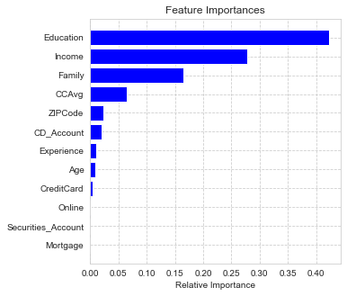

```python
importances = decision_tree.feature_importances_
index = np.argsort(importances)

plt.figure(figsize=(5,5))
plt.title('Feature Importances')
plt.barh(range(len(index)), importances[index], color='blue')
plt.yticks(range(len(index)), [feature_names[i] for i in index])
plt.xlabel('Relative Importance')
plt.show()
```

#### Insights from the decision tree

- according to the decision tree, the most important feature is education when it comes to accepting a loan
- the second most important feature is income
- the third most important feature is familt size

```python
scores(decision_tree,X_train, y_train, X_test, y_test )
```

```
Accuracy on training set :  1.0
Accuracy on test set :  0.9813333333333333

Recall on training set :  1.0
Recall on test set :  0.9295774647887324

Precision on training set :  1.0
Precision on test set :  0.88
```

### Insights on the decision tree

- In this model, the most important characteristic is giving loans to customers that will accept them
- The bank will lose the most by not giving loans out to people who would accept them
- We should focus on recall when looking at this model
- In this model, the test recall is 0.93

## Pre pruning the tree

```python
dtree1 = DecisionTreeClassifier(criterion = 'gini',max_depth=3,random_state=1)
dtree1.fit(X_train, y_train)
```

```
DecisionTreeClassifier(max_depth=3, random_state=1)
```

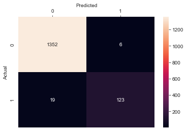

```python
y_predict = dtree1.predict(X_test)
dtree1_predict = y_predict.copy()

confusion_matrix=metrics.confusion_matrix(y_test, y_predict)
df_confusion = pd.DataFrame(confusion_matrix)

f, ax = plt.subplots(figsize=(6, 4))
sns.heatmap(df_confusion, annot=True, fmt="d")
ax.xaxis.set_ticks_position('top')
ax.xaxis.set_label_position('top')
plt.ylabel("Actual")
plt.xlabel("Predicted")
```

```python
#misclassified decision tree pre pruned with max depth

dtree1_predict = y_predict.copy()

pred_class  = np.where(dtree1_predict >0.5, "Yes", "No") #for binary(Yes/No) category
predictions = pd.DataFrame(pred_class, columns=['dtree1_predict'])
my_new_df_dtree1 = pd.concat([loans1, predictions], axis =1)
# loans_out = X_test.reset_index()
# loans_out["Actual"] = y_test.reset_index()["Columns_Name"]
# loans_out["Prediction"] = y_hats.reset_index()[0]
# loans["log_reg_predict"] = log_reg_predict
# df_out_log = pd.merge(loans,y_test[['log_reg_predict']],how = 'left',left_index = True, right_index = True)
# df_out_log
```

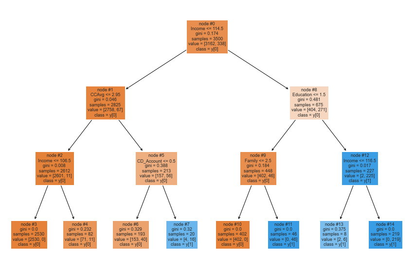

```python
plt.figure(figsize=(15,10))

out =tree.plot_tree(dtree1,feature_names=feature_names,filled=True,fontsize=9,node_ids=True,class_names=True)
for o in out:
    arrow = o.arrow_patch
    if arrow is not None:
        arrow.set_edgecolor('black')
        arrow.set_linewidth(1)

plt.show()
```

```python
print (pd.DataFrame(dtree1.feature_importances_, columns = ["Importance"], index = X_train.columns).sort_values(by = 'Importance', ascending = False))
```

```
                    Importance
Education             0.458474
Income                0.307068
Family                0.159109
CCAvg                 0.050806
CD_Account            0.024543
Age                   0.000000
Experience            0.000000
ZIPCode               0.000000
Mortgage              0.000000
Securities_Account    0.000000
Online                0.000000
CreditCard            0.000000
```

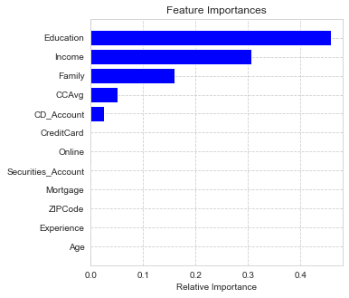

```python
importances = dtree1.feature_importances_
index = np.argsort(importances)

plt.figure(figsize=(5,5))
plt.title('Feature Importances')
plt.barh(range(len(index)), importances[index], color='blue')
plt.yticks(range(len(index)), [feature_names[i] for i in index])
plt.xlabel('Relative Importance')
plt.show()
```

### Insights after pre pruning the decision tree with max depth:

- education is still the most important feature
- income is still the second most important, and family is the thrid most important feature
- zipcode is no longer important
- experience and credit card are no longer an important feature

```python
scores(dtree1,X_train, y_train, X_test, y_test )
```

```
Accuracy on training set :  0.9837142857142858
Accuracy on test set :  0.9833333333333333

Recall on training set :  0.849112426035503
Recall on test set :  0.8661971830985915

Precision on training set :  0.9795221843003413
Precision on test set :  0.9534883720930233
```

#### insights on the model metrics after pre pruning:

- after pre-pruning, the test recall decreased to 0.87
- perhaps pre pruning is not the way to go

## Hyperparameter pruning using Grid Search

```python
# Choose the type of classifier.
estimate = DecisionTreeClassifier(random_state=4)

# Grid of parameters to choose from
## add from article
parameters = {'max_depth': np.arange(1,10),
              'min_samples_leaf': [1, 2, 5, 7, 10,15,20],
              'max_leaf_nodes' : [2, 3, 5, 10]
             }

# Type of scoring used to compare parameter combinations
acc_scorer = metrics.make_scorer(metrics.recall_score)

# Run the grid search
grid_obj = GridSearchCV(estimate, parameters, scoring=acc_scorer,cv=5)
grid_obj = grid_obj.fit(X_train, y_train)

# Set the clf to the best combination of parameters
estimate = grid_obj.best_estimator_

# Fit the best algorithm to the data.
estimate.fit(X_train, y_train)
```

```
DecisionTreeClassifier(max_depth=6, max_leaf_nodes=10, random_state=4)
```

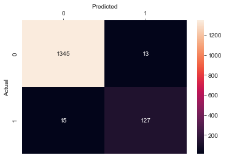

```python
y_predict = estimate.predict(X_test)

confusion_matrix=metrics.confusion_matrix(y_test, y_predict)
df_confusion = pd.DataFrame(confusion_matrix)

f, ax = plt.subplots(figsize=(6, 4))
sns.heatmap(df_confusion, annot=True, fmt="d")
ax.xaxis.set_ticks_position('top')
ax.xaxis.set_label_position('top')
plt.ylabel("Actual")
plt.xlabel("Predicted")
```

```python
#misclassified decision tree pre pruned with hyperparameter

estimate_predict = y_predict.copy()

pred_class  = np.where(estimate_predict >0.5, "Yes", "No") #for binary(Yes/No) category
predictions = pd.DataFrame(pred_class, columns=['estimate_hyper_predict'])
my_new_df_estimate = pd.concat([loans1, predictions], axis =1)
# loans_out = X_test.reset_index()
# loans_out["Actual"] = y_test.reset_index()["Columns_Name"]
# loans_out["Prediction"] = y_hats.reset_index()[0]
# loans["log_reg_predict"] = log_reg_predict
# df_out_log = pd.merge(loans,y_test[['log_reg_predict']],how = 'left',left_index = True, right_index = True)
# df_out_log
```

```python
scores(estimate,X_train, y_train, X_test, y_test )
```

```
Accuracy on training set :  0.9877142857142858
Accuracy on test set :  0.9813333333333333

Recall on training set :  0.8964497041420119
Recall on test set :  0.8943661971830986

Precision on training set :  0.9742765273311897
Precision on test set :  0.9071428571428571
```

#### Insights on metrics from hyperparameter tuning:

- test recall has increased back up to 0.89, which is better than pre pruning but not as good as the original model

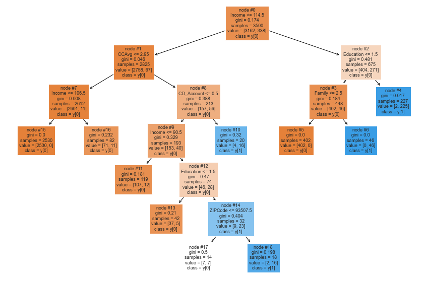

```python
plt.figure(figsize=(15,10))

out =tree.plot_tree(estimate,feature_names=feature_names,filled=True,fontsize=9,node_ids=True,class_names=True)
for o in out:
    arrow = o.arrow_patch
    if arrow is not None:
        arrow.set_edgecolor('black')
        arrow.set_linewidth(1)
plt.show()
```

```python
print (pd.DataFrame(estimate.feature_importances_, columns = ["Importance"], index = X_train.columns).sort_values(by = 'Importance', ascending = False))
```

```
                    Importance
Education             0.464399
Income                0.306067
Family                0.152775
CCAvg                 0.048783
CD_Account            0.023566
ZIPCode               0.004408
Age                   0.000000
Experience            0.000000
Mortgage              0.000000
Securities_Account    0.000000
Online                0.000000
CreditCard            0.000000
```

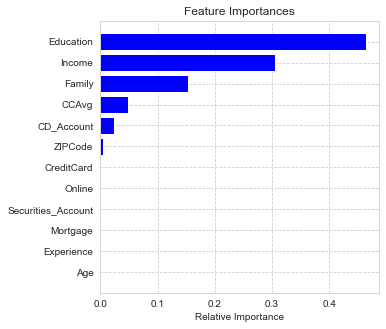

```python
importances = estimate.feature_importances_
index = np.argsort(importances)

plt.figure(figsize=(5,5))
plt.title('Feature Importances')
plt.barh(range(len(index)), importances[index], color='blue')
plt.yticks(range(len(index)), [feature_names[i] for i in index])
plt.xlabel('Relative Importance')
plt.show()
```

### Insights from hyperparameter tuning

- the top 3 feautures are still the same, education, income and family (in that order) will have the most importance on the customer accepting a loan if offered
- zip code is again an important feature using hyperparameter tuning

### Post pruning the tree

```python
post = DecisionTreeClassifier(random_state=1)
path = post.cost_complexity_pruning_path(X_train, y_train)
ccp_alphas, impurities = path.ccp_alphas, path.impurities
```

```python
pd.DataFrame(path)
```

|  | ccp_alphas | impurities |
| --- | --- | --- |
| 0 | 0.000000 | 0.000000 |
| 1 | 0.000214 | 0.000429 |
| 2 | 0.000245 | 0.000918 |
| 3 | 0.000265 | 0.001980 |
| 4 | 0.000281 | 0.002541 |
| 5 | 0.000316 | 0.004124 |
| 6 | 0.000324 | 0.005746 |
| 7 | 0.000378 | 0.006879 |
| 8 | 0.000381 | 0.007260 |
| 9 | 0.000455 | 0.008170 |
| 10 | 0.000490 | 0.008660 |
| 11 | 0.000508 | 0.009676 |
| 12 | 0.000554 | 0.010229 |
| 13 | 0.000577 | 0.011960 |
| 14 | 0.000637 | 0.014510 |
| 15 | 0.000716 | 0.015942 |
| 16 | 0.000720 | 0.018102 |
| 17 | 0.000817 | 0.018919 |
| 18 | 0.000889 | 0.019808 |
| 19 | 0.000896 | 0.021600 |
| 20 | 0.002870 | 0.027341 |
| 21 | 0.003638 | 0.030979 |
| 22 | 0.007532 | 0.038510 |
| 23 | 0.023587 | 0.062097 |
| 24 | 0.056197 | 0.174491 |

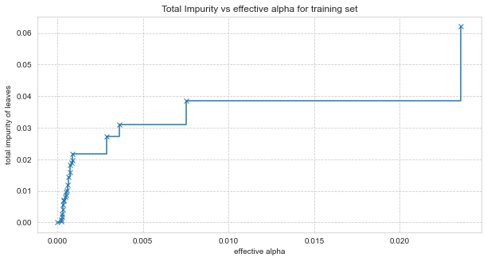

```python
fig, ax = plt.subplots(figsize=(10,5))
ax.plot(ccp_alphas[:-1], impurities[:-1], marker='x', drawstyle="steps-post")
ax.set_xlabel("effective alpha")
ax.set_ylabel("total impurity of leaves")
ax.set_title("Total Impurity vs effective alpha for training set")
plt.show()
```

```python
clfs = []
for ccp_alpha in ccp_alphas:
    clf = DecisionTreeClassifier(random_state=1, ccp_alpha=ccp_alpha)
    clf.fit(X_train, y_train)
    clfs.append(clf)
print("Number of nodes in the last tree is: {} with ccp_alpha: {}".format(
      clfs[-1].tree_.node_count, ccp_alphas[-1]))
```

```
Number of nodes in the last tree is: 1 with ccp_alpha: 0.05619677689217671
```

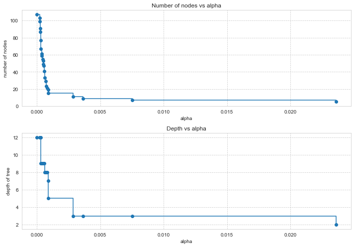

```python
clfs = clfs[:-1]
ccp_alphas = ccp_alphas[:-1]

node_counts = [clf.tree_.node_count for clf in clfs]
depth = [clf.tree_.max_depth for clf in clfs]
fig, ax = plt.subplots(2, 1,figsize=(10,7))
ax[0].plot(ccp_alphas, node_counts, marker='o', drawstyle="steps-post")
ax[0].set_xlabel("alpha")
ax[0].set_ylabel("number of nodes")
ax[0].set_title("Number of nodes vs alpha")
ax[1].plot(ccp_alphas, depth, marker='o', drawstyle="steps-post")
ax[1].set_xlabel("alpha")
ax[1].set_ylabel("depth of tree")
ax[1].set_title("Depth vs alpha")
fig.tight_layout()
```

```python
train_scores = [clf.score(X_train, y_train) for clf in clfs]
test_scores = [clf.score(X_test, y_test) for clf in clfs]
```

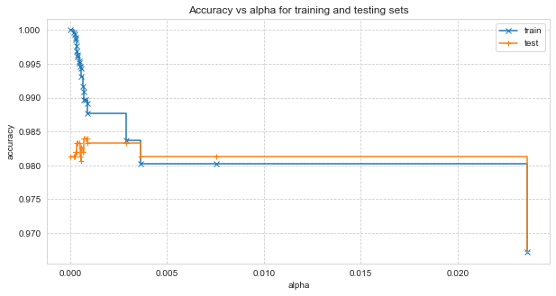

```python
fig, ax = plt.subplots(figsize=(10,5))
ax.set_xlabel("alpha")
ax.set_ylabel("accuracy")
ax.set_title("Accuracy vs alpha for training and testing sets")
ax.plot(ccp_alphas, train_scores, marker='x', label="train",
        drawstyle="steps-post")
ax.plot(ccp_alphas, test_scores, marker='+', label="test",
        drawstyle="steps-post")
ax.legend()
plt.show()
```

```python
index_best_model = np.argmax(test_scores)
best_model = clfs[index_best_model]
print(best_model)

print('Training accuracy of best model: ',best_model.score(X_train, y_train))
print('Test accuracy of best model: ',best_model.score(X_test, y_test))
```

```
DecisionTreeClassifier(ccp_alpha=0.0007162086073367407, random_state=1)
Training accuracy of best model:  0.9908571428571429
Test accuracy of best model:  0.984
```

```python
recall_train=[]
for clf in clfs:
    pred_train3=clf.predict(X_train)
    values_train=metrics.recall_score(y_train,pred_train3)
    recall_train.append(values_train)
```

```python
recall_test=[]
for clf in clfs:
    pred_test3=clf.predict(X_test)
    values_test=metrics.recall_score(y_test,pred_test3)
    recall_test.append(values_test)
```

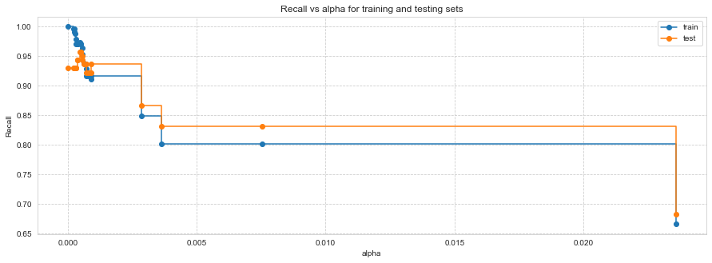

```python
fig, ax = plt.subplots(figsize=(15,5))
ax.set_xlabel("alpha")
ax.set_ylabel("Recall")
ax.set_title("Recall vs alpha for training and testing sets")
ax.plot(ccp_alphas, recall_train, marker='o', label="train",
        drawstyle="steps-post")
ax.plot(ccp_alphas, recall_test, marker='o', label="test",
        drawstyle="steps-post")
ax.legend()
plt.show()
```

```python
# creating the model where we get highest train and test recall
index_best_model = np.argmax(recall_test)
best_model = clfs[index_best_model]
print(best_model)
```

```
DecisionTreeClassifier(ccp_alpha=0.00045510204081632627, random_state=1)
```

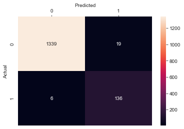

```python
y_predict = best_model.predict(X_test)

confusion_matrix=metrics.confusion_matrix(y_test, y_predict)
df_confusion = pd.DataFrame(confusion_matrix)

f, ax = plt.subplots(figsize=(6, 4))
sns.heatmap(df_confusion, annot=True, fmt="d")
ax.xaxis.set_ticks_position('top')
ax.xaxis.set_label_position('top')
plt.ylabel("Actual")
plt.xlabel("Predicted")
```

```python
#misclassified decision tree post pruned

best_model_predict = y_predict.copy()

pred_class  = np.where(best_model_predict >0.5, "Yes", "No") #for binary(Yes/No) category
predictions = pd.DataFrame(pred_class, columns=['best_model_predict'])
my_new_df_best_model = pd.concat([loans1, predictions], axis =1)
```

```python
scores(best_model,X_train, y_train, X_test, y_test )
```

```
Accuracy on training set :  0.9954285714285714
Accuracy on test set :  0.9833333333333333

Recall on training set :  0.9733727810650887
Recall on test set :  0.9577464788732394

Precision on training set :  0.9791666666666666
Precision on test set :  0.8774193548387097
```

### Insights from post pruning:

- recall is the highest in post pruning ompared to the original decision tree, pre pruning, and hyperparameter tuning

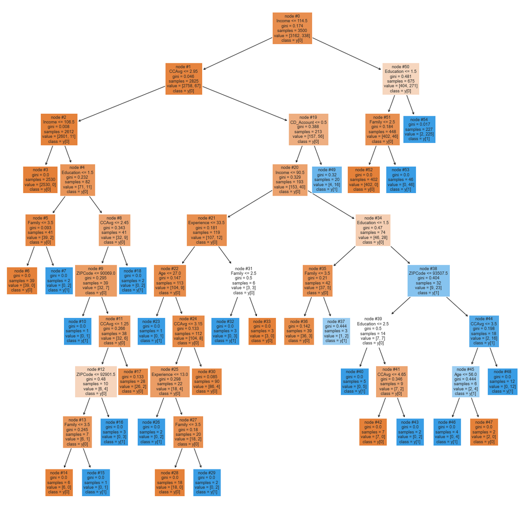

```python
plt.figure(figsize=(20,20))

out =tree.plot_tree(best_model,feature_names=feature_names,filled=True,fontsize=9,node_ids=True,class_names=True)
for o in out:
    arrow = o.arrow_patch
    if arrow is not None:
        arrow.set_edgecolor('black')
        arrow.set_linewidth(1)
plt.show()
```

```python
print (pd.DataFrame(best_model.feature_importances_, columns = ["Imp"], index = X_train.columns).sort_values(by = 'Imp', ascending = False))
```

```
                         Imp
Education           0.439816
Income              0.284109
Family              0.165962
CCAvg               0.060435
CD_Account          0.021876
ZIPCode             0.011767
Experience          0.008519
Age                 0.007517
Mortgage            0.000000
Securities_Account  0.000000
Online              0.000000
CreditCard          0.000000
```

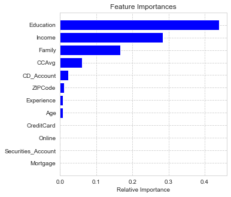

```python
importances = best_model.feature_importances_
index = np.argsort(importances)

plt.figure(figsize=(5,5))
plt.title('Feature Importances')
plt.barh(range(len(index)), importances[index], color='blue')
plt.yticks(range(len(index)), [feature_names[i] for i in index])
plt.xlabel('Relative Importance')
plt.show()
```

### Insights from post pruning:

```python
##to generate comparison frame
# scores(model,X_train, y_train, X_test, y_test )
# scores(estimate,X_train, y_train, X_test, y_test )
# scores(decision_tree,X_train, y_train, X_test, y_test )
# scores(dtree1,X_train, y_train, X_test, y_test )
# scores(best_model,X_train, y_train, X_test, y_test )

comparison_frame = pd.DataFrame({'Model':['Initial decision tree model','Decision tree with restricted maximum depth','Decision treee with hyperparameter tuning',
                                         'Decision tree with post-pruning', "Original Logistic Regression", "Optimized Logistic Regression"],
                                 'Train_Recall':[1,0.85,0.90,0.97,0.31, 0.51 ],
                                 'Test_Recall':[0.923,0.87,0.89,0.96, 0.30, 0.53]})
comparison_frame
```

[output not shown]

#### Misclassified data

```python
loans.head()
loans.describe()
```

|  | Age | Experience | Income | ZIPCode | Family | CCAvg | Education | Mortgage | Personal_Loan | Securities_Account | CD_Account | Online | CreditCard |
| --- | --- | --- | --- | --- | --- | --- | --- | --- | --- | --- | --- | --- | --- |
| count | 5000.000000 | 5000.000000 | 5000.000000 | 5000.000000 | 5000.000000 | 5000.000000 | 5000.000000 | 5000.000000 | 5000.000000 | 5000.000000 | 5000.00000 | 5000.000000 | 5000.000000 |
| mean | 45.338400 | 20.327600 | 73.774200 | 93169.257000 | 2.396400 | 1.937938 | 1.881000 | 56.498800 | 0.096000 | 0.104400 | 0.06040 | 0.596800 | 0.294000 |
| std | 11.463166 | 11.253035 | 46.033729 | 1759.455086 | 1.147663 | 1.747659 | 0.839869 | 101.713802 | 0.294621 | 0.305809 | 0.23825 | 0.490589 | 0.455637 |
| min | 23.000000 | 0.000000 | 8.000000 | 90005.000000 | 1.000000 | 0.000000 | 1.000000 | 0.000000 | 0.000000 | 0.000000 | 0.00000 | 0.000000 | 0.000000 |
| 25% | 35.000000 | 11.000000 | 39.000000 | 91911.000000 | 1.000000 | 0.700000 | 1.000000 | 0.000000 | 0.000000 | 0.000000 | 0.00000 | 0.000000 | 0.000000 |
| 50% | 45.000000 | 20.000000 | 64.000000 | 93437.000000 | 2.000000 | 1.500000 | 2.000000 | 0.000000 | 0.000000 | 0.000000 | 0.00000 | 1.000000 | 0.000000 |
| 75% | 55.000000 | 30.000000 | 98.000000 | 94608.000000 | 3.000000 | 2.500000 | 3.000000 | 101.000000 | 0.000000 | 0.000000 | 0.00000 | 1.000000 | 1.000000 |
| max | 67.000000 | 43.000000 | 224.000000 | 96651.000000 | 4.000000 | 10.000000 | 3.000000 | 635.000000 | 1.000000 | 1.000000 | 1.00000 | 1.000000 | 1.000000 |

```python
#log regression model misclassification

my_new_df_log = my_new_df_log[my_new_df_log['log_reg_predict'].notna()]
my_new_df_log = my_new_df_log[my_new_df_log.log_reg_predict != "No"]
my_new_df_log.sample(n = 7)
my_new_df_log.describe()
```

|  | Age | Experience | Income | ZIPCode | Family | CCAvg | Education | Mortgage | Personal_Loan | Securities_Account | CD_Account | Online | CreditCard |
| --- | --- | --- | --- | --- | --- | --- | --- | --- | --- | --- | --- | --- | --- |
| count | 69.000000 | 69.000000 | 69.000000 | 69.000000 | 69.000000 | 69.000000 | 69.000000 | 69.000000 | 69.000000 | 69.000000 | 69.000000 | 69.000000 | 69.000000 |
| mean | 47.594203 | 22.695652 | 80.840580 | 93383.840580 | 2.449275 | 2.278406 | 1.666667 | 61.420290 | 0.072464 | 0.086957 | 0.043478 | 0.608696 | 0.217391 |
| std | 11.605423 | 11.086962 | 50.101257 | 1648.052225 | 1.064621 | 1.981156 | 0.779643 | 112.760079 | 0.261154 | 0.283836 | 0.205425 | 0.491618 | 0.415493 |
| min | 23.000000 | 0.000000 | 8.000000 | 90032.000000 | 1.000000 | 0.000000 | 1.000000 | 0.000000 | 0.000000 | 0.000000 | 0.000000 | 0.000000 | 0.000000 |
| 25% | 40.000000 | 14.000000 | 43.000000 | 92346.000000 | 2.000000 | 0.700000 | 1.000000 | 0.000000 | 0.000000 | 0.000000 | 0.000000 | 0.000000 | 0.000000 |
| 50% | 50.000000 | 25.000000 | 64.000000 | 94025.000000 | 2.000000 | 1.670000 | 1.000000 | 0.000000 | 0.000000 | 0.000000 | 0.000000 | 1.000000 | 0.000000 |
| 75% | 57.000000 | 32.000000 | 114.000000 | 94596.000000 | 3.000000 | 2.900000 | 2.000000 | 111.000000 | 0.000000 | 0.000000 | 0.000000 | 1.000000 | 0.000000 |
| max | 66.000000 | 42.000000 | 204.000000 | 95827.000000 | 4.000000 | 7.600000 | 3.000000 | 433.000000 | 1.000000 | 1.000000 | 1.000000 | 1.000000 | 1.000000 |

```python
#decision tree misclassification


my_new_df_dtree = my_new_df_dtree[my_new_df_dtree['dtree_predict'].notna()]
my_new_df_dtree = my_new_df_dtree[my_new_df_dtree.dtree_predict != "No"]

my_new_df_dtree.shape
my_new_df_dtree.sample(n = 7)
my_new_df_dtree.describe()
```

|  | Age | Experience | Income | ZIPCode | Family | CCAvg | Education | Mortgage | Personal_Loan | Securities_Account | CD_Account | Online | CreditCard |
| --- | --- | --- | --- | --- | --- | --- | --- | --- | --- | --- | --- | --- | --- |
| count | 150.000000 | 150.000000 | 150.000000 | 150.000000 | 150.000000 | 150.000000 | 150.000000 | 150.000000 | 150.000000 | 150.000000 | 150.000000 | 150.000000 | 150.000000 |
| mean | 44.466667 | 19.426667 | 69.146667 | 93286.500000 | 2.466667 | 1.687533 | 1.813333 | 41.826667 | 0.073333 | 0.100000 | 0.066667 | 0.613333 | 0.253333 |
| std | 11.407443 | 11.088023 | 42.762554 | 1747.160595 | 1.207731 | 1.703724 | 0.822394 | 77.112377 | 0.261556 | 0.301005 | 0.250279 | 0.488618 | 0.436377 |
| min | 24.000000 | 0.000000 | 10.000000 | 90024.000000 | 1.000000 | 0.000000 | 1.000000 | 0.000000 | 0.000000 | 0.000000 | 0.000000 | 0.000000 | 0.000000 |
| 25% | 35.000000 | 10.000000 | 38.000000 | 92007.500000 | 1.000000 | 0.525000 | 1.000000 | 0.000000 | 0.000000 | 0.000000 | 0.000000 | 0.000000 | 0.000000 |
| 50% | 45.000000 | 20.000000 | 61.000000 | 94034.000000 | 2.000000 | 1.400000 | 2.000000 | 0.000000 | 0.000000 | 0.000000 | 0.000000 | 1.000000 | 0.000000 |
| 75% | 53.000000 | 28.000000 | 88.000000 | 94720.000000 | 4.000000 | 2.175000 | 3.000000 | 87.750000 | 0.000000 | 0.000000 | 0.000000 | 1.000000 | 0.750000 |
| max | 67.000000 | 42.000000 | 202.000000 | 95841.000000 | 4.000000 | 10.000000 | 3.000000 | 333.000000 | 1.000000 | 1.000000 | 1.000000 | 1.000000 | 1.000000 |

```python
#miscalssified pre pruned decision tree with max depth

my_new_df_dtree1 = my_new_df_dtree1[my_new_df_dtree1['dtree1_predict'].notna()]
my_new_df_dtree1 = my_new_df_dtree1[my_new_df_dtree1.dtree1_predict != "No"]
my_new_df_dtree1.head()
my_new_df_dtree1.sample(n = 6)
my_new_df_dtree1.describe()
```

|  | Age | Experience | Income | ZIPCode | Family | CCAvg | Education | Mortgage | Personal_Loan | Securities_Account | CD_Account | Online | CreditCard |
| --- | --- | --- | --- | --- | --- | --- | --- | --- | --- | --- | --- | --- | --- |
| count | 129.000000 | 129.000000 | 129.000000 | 129.000000 | 129.000000 | 129.000000 | 129.000000 | 129.000000 | 129.000000 | 129.000000 | 129.000000 | 129.000000 | 129.000000 |
| mean | 44.813953 | 19.720930 | 64.372093 | 93176.992248 | 2.472868 | 1.536434 | 1.775194 | 40.085271 | 0.054264 | 0.093023 | 0.046512 | 0.604651 | 0.248062 |
| std | 11.301111 | 10.986481 | 40.822227 | 1768.830981 | 1.231599 | 1.629066 | 0.802733 | 72.522737 | 0.227420 | 0.291597 | 0.211411 | 0.490832 | 0.433572 |
| min | 24.000000 | 0.000000 | 10.000000 | 90024.000000 | 1.000000 | 0.000000 | 1.000000 | 0.000000 | 0.000000 | 0.000000 | 0.000000 | 0.000000 | 0.000000 |
| 25% | 35.000000 | 10.000000 | 34.000000 | 91902.000000 | 1.000000 | 0.400000 | 1.000000 | 0.000000 | 0.000000 | 0.000000 | 0.000000 | 0.000000 | 0.000000 |
| 50% | 46.000000 | 21.000000 | 50.000000 | 94022.000000 | 2.000000 | 1.000000 | 2.000000 | 0.000000 | 0.000000 | 0.000000 | 0.000000 | 1.000000 | 0.000000 |
| 75% | 53.000000 | 28.000000 | 83.000000 | 94607.000000 | 4.000000 | 2.100000 | 2.000000 | 87.000000 | 0.000000 | 0.000000 | 0.000000 | 1.000000 | 0.000000 |
| max | 67.000000 | 42.000000 | 191.000000 | 95841.000000 | 4.000000 | 8.600000 | 3.000000 | 333.000000 | 1.000000 | 1.000000 | 1.000000 | 1.000000 | 1.000000 |

```python
my_new_df_estimate = my_new_df_estimate[my_new_df_estimate['estimate_hyper_predict'].notna()]
my_new_df_estimate = my_new_df_estimate[my_new_df_estimate.estimate_hyper_predict != "No"]
my_new_df_estimate.head()
my_new_df_estimate.sample(n=6)
my_new_df_estimate.describe()
```

|  | Age | Experience | Income | ZIPCode | Family | CCAvg | Education | Mortgage | Personal_Loan | Securities_Account | CD_Account | Online | CreditCard |
| --- | --- | --- | --- | --- | --- | --- | --- | --- | --- | --- | --- | --- | --- |
| count | 140.000000 | 140.000000 | 140.000000 | 140.000000 | 140.000000 | 140.000000 | 140.000000 | 140.000000 | 140.000000 | 140.000000 | 140.000000 | 140.000000 | 140.000000 |
| mean | 44.850000 | 19.735714 | 65.800000 | 93250.828571 | 2.421429 | 1.575000 | 1.785714 | 42.642857 | 0.064286 | 0.107143 | 0.064286 | 0.607143 | 0.257143 |
| std | 11.267784 | 10.956166 | 40.284635 | 1750.992639 | 1.223674 | 1.595086 | 0.811657 | 77.172522 | 0.246142 | 0.310405 | 0.246142 | 0.490139 | 0.438628 |
| min | 24.000000 | 0.000000 | 10.000000 | 90024.000000 | 1.000000 | 0.000000 | 1.000000 | 0.000000 | 0.000000 | 0.000000 | 0.000000 | 0.000000 | 0.000000 |
| 25% | 35.750000 | 10.000000 | 37.250000 | 92007.000000 | 1.000000 | 0.400000 | 1.000000 | 0.000000 | 0.000000 | 0.000000 | 0.000000 | 0.000000 | 0.000000 |
| 50% | 46.000000 | 20.500000 | 53.000000 | 94025.000000 | 2.000000 | 1.250000 | 2.000000 | 0.000000 | 0.000000 | 0.000000 | 0.000000 | 1.000000 | 0.000000 |
| 75% | 53.250000 | 28.000000 | 84.250000 | 94632.750000 | 4.000000 | 2.100000 | 2.000000 | 87.250000 | 0.000000 | 0.000000 | 0.000000 | 1.000000 | 1.000000 |
| max | 67.000000 | 42.000000 | 191.000000 | 95841.000000 | 4.000000 | 8.600000 | 3.000000 | 333.000000 | 1.000000 | 1.000000 | 1.000000 | 1.000000 | 1.000000 |

```python
my_new_df_best_model = my_new_df_best_model[my_new_df_best_model['best_model_predict'].notna()]
my_new_df_best_model = my_new_df_best_model[my_new_df_best_model.best_model_predict != "No"]
my_new_df_best_model.head()
my_new_df_best_model.describe()
```

|  | Age | Experience | Income | ZIPCode | Family | CCAvg | Education | Mortgage | Personal_Loan | Securities_Account | CD_Account | Online | CreditCard |
| --- | --- | --- | --- | --- | --- | --- | --- | --- | --- | --- | --- | --- | --- |
| count | 155.000000 | 155.000000 | 155.000000 | 155.000000 | 155.000000 | 155.000000 | 155.000000 | 155.000000 | 155.000000 | 155.000000 | 155.000000 | 155.000000 | 155.000000 |
| mean | 44.832258 | 19.780645 | 68.122581 | 93238.587097 | 2.470968 | 1.653097 | 1.825806 | 41.032258 | 0.070968 | 0.103226 | 0.064516 | 0.593548 | 0.251613 |
| std | 11.350279 | 10.984801 | 42.549946 | 1737.696056 | 1.213076 | 1.691232 | 0.822953 | 76.258823 | 0.257603 | 0.305240 | 0.246466 | 0.492763 | 0.435347 |
| min | 24.000000 | 0.000000 | 10.000000 | 90024.000000 | 1.000000 | 0.000000 | 1.000000 | 0.000000 | 0.000000 | 0.000000 | 0.000000 | 0.000000 | 0.000000 |
| 25% | 35.500000 | 10.000000 | 38.000000 | 91954.500000 | 1.000000 | 0.450000 | 1.000000 | 0.000000 | 0.000000 | 0.000000 | 0.000000 | 0.000000 | 0.000000 |
| 50% | 45.000000 | 20.000000 | 55.000000 | 94025.000000 | 2.000000 | 1.400000 | 2.000000 | 0.000000 | 0.000000 | 0.000000 | 0.000000 | 1.000000 | 0.000000 |
| 75% | 53.000000 | 28.000000 | 85.000000 | 94703.500000 | 4.000000 | 2.100000 | 3.000000 | 85.000000 | 0.000000 | 0.000000 | 0.000000 | 1.000000 | 0.500000 |
| max | 67.000000 | 42.000000 | 202.000000 | 95841.000000 | 4.000000 | 10.000000 | 3.000000 | 333.000000 | 1.000000 | 1.000000 | 1.000000 | 1.000000 | 1.000000 |

### Insights on Logistic regression versus Decision trees

- the metric used to compare the two models and trainig vs testing data was recall
- recall was chosen because the bank takes the largest loss by not offering the loan to customers who would have taken the loan if it were offered
  - in order to decrease this number (the number of false negatives), we must increase the recall score
- the best test recall score on the logistic regresission analysis was obtained with an optimized regression, and the maximum test recall score was 0.53
- conversely, the lowest test recall from the decision tree was with a pre pruned tree on a maximum depth (recall = 0.87)
- the best test recall score was achieved with a post-pruned tree, with a recall score of 0.96

# Conclusion and Recomendations for the bank and its marketing team

- Based on the data from the model, the marketing team should focus on the following features when offering loans to increase their revenue from loans:
  - education level
  - income level
  - family size
- as the values of these features increase, so too will the probability that the customers accept an offered loan
- the bank will make the most money as they offer customers with a large income, high education level, and increased family size, since they are most likely to accept loans